# Optimización de Cadenas de Colaboración Musical en Spotify

Author

Laura López, Candela Hebles y Lucía Rodríguez

## 1 Enunciado del problema

Somos una discográfica musical que quiere preparar un álbum formado por dúos inéditos. Contamos con un catálogo de canciones que indica que artistas participaron en cada tema, y recoge datos sobre su popularidad, estilo y características sonoras.

Queremos proponer parejas que nunca hayan grabado juntos que se muevan en círculos cercanos. Además, buscamos que la pareja sea prometedora desde el punto de vista musical: que sus sonidos sean compatibles y que procedan de estilos distintos para aportar versaatilidad al álbum.

¿Qué parejas deberíamos proponer para que el conjunto del álbum sea lo más atractivo posible?

## 2 Datos utilizados

Hemos elegido el dataset “Spotify Tracks Dataset | Audio Features” publicado en Kaggle [^1]. El dataset contiene información sobre canciones de Spotify, los artistas participantes, la popularidad, el género y diversas características de audio. Según la descripción del dataset, la información se recopiló mediante la API de Spotify.

## 3 Diferencias con un problema de transporte o distribución

Nuestro caso no es un problema de transporte o distribución, ya que no modelamos el traslado ni el reparto de productos entre puntos de origen y destino, no hay nada que circule, solo se decide quién se empareja con quién, con la condición de que cada artista participe como máximo en un dúo. La red de colaboraciones tampoco es bipartita, ya que contiene ciclos impares, por lo que el emparejamiento lo plantearemos en un grafo general. Necesitamos dos modelos porque responden a preguntas distintas: los caminos mínimos, calculados con Dijkstra, miden la cercanía entre artistas, lo que permite determinar qué parejas inéditas son elegibles y puntuar su viabilidad. Después, el emparejamiento de máximo peso selecciona el conjunto de parejas compatibles que maximiza la puntuación total. Así, el primer modelo evalúa cada posible pareja y el segundo tiene en cuenta que las elecciones compiten por los mismos artistas.

## 4 Preparación de los datos

El conjunto de datos empleado contiene aproximadamente 114.000 canciones obtenidas de Spotify. Para construir la red de colaboraciones fue necesario realizar un proceso previo de limpieza y transformación de los datos.

### 4.1 Selección de variables

De todas las variables disponibles en el conjunto de datos se utilizó principalmente la columna ‘artists’, que identifica los artistas participantes en cada canción.

### 4.2 Selección de artistas

El conjunto de datos contiene miles de artistas diferentes. Con el objetivo de obtener una red representativa y computacionalmente manejable, se seleccionaron los 300 artistas con mayor número de apariciones en las canciones del dataset.

A partir de este momento, todos los análisis y modelos desarrollados en el trabajo se realizan exclusivamente sobre este subconjunto de artistas.

### 4.3 Tratamientro de colaboraciones

Se observó que los artistas colaboradores aparecen separados mediante el carácter “;” dentro de la columna `artists`.

Por ejemplo:

- Geo
- Ben Woodward
- Ingrid Michaelson;ZAYN

Por ello, cada registro fue dividido utilizando dicho separador para identificar correctamente a todos los artistas participantes en una canción.

### 4.4 Construcción de las parejas de colaboración

Una vez identificados los artistas de cada canción, se generaron todas las parejas posibles de colaboradores.

Si una canción contiene los artistas:

A;B;C

se generan las colaboraciones:

- A-B
- A-C
- B-C

Posteriormente se contó el número total de colaboraciones entre cada pareja de artistas.

### 4.5 Implementación

**Mostrar código**

```python
import pandas as pd
import networkx as nx
from itertools import combinations
from collections import defaultdict
import matplotlib.pyplot as plt

df = pd.read_csv("spotify-tracks-dataset-detailed.csv")
from collections import Counter

conteo_artistas = Counter()

for artistas in df["artists"].dropna():

    lista = [a.strip() for a in str(artistas).split(";")]

    for artista in lista:
        conteo_artistas[artista] += 1

top_artistas_df = pd.DataFrame(
    conteo_artistas.items(),
    columns=["Artista", "Número de canciones"]
)

top_artistas_df = top_artistas_df.sort_values(
    by="Número de canciones",
    ascending=False
)

top_artistas_df = top_artistas_df.head(300)

# Renumerar filas desde 1 hasta 300
top_artistas_df = top_artistas_df.reset_index(drop=True)
top_artistas_df.index = top_artistas_df.index + 1

top_artistas = set(
    top_artistas_df["Artista"]
)

top_artistas_df.head(30)
```

|  | Artista | Número de canciones |
| --- | --- | --- |
| 1 | J Balvin | 510 |
| 2 | Bad Bunny | 416 |
| 3 | Daddy Yankee | 375 |
| 4 | Wolfgang Amadeus Mozart | 354 |
| 5 | Feid | 348 |
| 6 | George Jones | 343 |
| 7 | Pritam | 333 |
| 8 | Arijit Singh | 305 |
| 9 | ILLENIUM | 298 |
| 10 | The Beatles | 280 |
| 11 | Jhayco | 269 |
| 12 | Ella Fitzgerald | 263 |
| 13 | Linkin Park | 253 |
| 14 | David Guetta | 250 |
| 15 | Hank Williams | 248 |
| 16 | Stevie Wonder | 239 |
| 17 | Don Omar | 234 |
| 18 | Yuvan Shankar Raja | 233 |
| 19 | Prateek Kuhad | 230 |
| 20 | KAROL G | 228 |
| 21 | Tiësto | 221 |
| 22 | Burna Boy | 214 |
| 23 | OneRepublic | 205 |
| 24 | Robin Schulz | 199 |
| 25 | Marshmello | 196 |
| 26 | Armin van Buuren | 194 |
| 27 | Chuck Berry | 190 |
| 28 | Ozuna | 185 |
| 29 | Håkan Hellström | 185 |
| 30 | Charlie Brown Jr. | 185 |

**Mostrar código**

```python
colaboraciones = defaultdict(int)

for artistas in df["artists"].dropna():

    lista = [a.strip() for a in str(artistas).split(";")]

    lista = [
        artista
        for artista in lista
        if artista in top_artistas
    ]

    lista = list(set(lista))

    if len(lista) < 2:
        continue

    for a, b in combinations(sorted(lista), 2):
        colaboraciones[(a, b)] += 1

print("Número de parejas:", len(colaboraciones))
```

```
Número de parejas: 376
```

## 5 Modelización del problema

El objetivo del proyecto es proponer nuevos duetos entre artistas a partir de las colaboraciones existentes en Spotify. Para ello, el problema se divide en dos fases complementarias.

En una primera fase se analiza la red de colaboraciones para medir la cercanía entre artistas. En una segunda fase se seleccionan las parejas finales de artistas que formarían los nuevos duetos. Esta división permite distinguir entre el análisis de la red existente y la optimización de las recomendaciones finales

### 5.1 Modelo 1: Medición de cercanía mediante caminos mínimos

El primer modelo tiene como objetivo estimar qué tan próximos se encuentran dos artistas dentro de la red de colaboraciones musicales.

#### 5.1.1 Construcción del grafo

Se define un grafo no dirigido $G=(V,E)$:

- Cada nodo representa uno de los 300 artistas seleccionados durante la fase de preparación de los datos.
- Existe una arista entre dos artistas si han participado conjuntamente en al menos una canción.
- El peso de cada arista depende del número de colaboraciones existentes entre ambos artistas.

Si dos artistas $i$ y $j$ han colaborado $n_{ij}$ veces, el coste asociado a la arista se define como:

$c_{ij}=\frac{1}{n_{ij}}$

De esta forma, cuanto mayor sea el número de colaboraciones compartidas, menor será la distancia entre ambos artistas.

#### 5.1.2 Problema a resolver

Dados dos artistas cualesquiera, se busca el camino de coste mínimo que los conecta dentro de la red.

La distancia entre dos artistas se obtiene sumando los costes de las aristas que forman el camino seleccionado:

$$\displaystyle d(i, j) = \min \sum_{(u,v) \in P} c_{uv}$$

donde $P$ representa cualquier camino válido entre los artistas $i$ y $j$.

#### 5.1.3 Interpretación

Un valor pequeño de distancia indica que dos artistas pertenecen a entornos musicales muy conectados, ya sea porque han colaborado directamente o porque están unidos por cadenas cortas de colaboraciones frecuentes.

El resultado de este modelo es una medida cuantitativa de proximidad entre artistas que posteriormente será utilizada para generar recomendaciones de nuevos duetos.

#### 5.1.4 Implementación en Python

A partir de las colaboraciones obtenidas durante la fase de preparación de datos se construye un grafo no dirigido. Cada nodo representa un artista y cada arista una colaboración existente.

**Mostrar código**

```python
G = nx.Graph()

for (a, b), n_colab in colaboraciones.items():

    G.add_edge(
        a,
        b,
        weight=1/n_colab,
        collaborations=n_colab
    )

print("Número de artistas:", G.number_of_nodes())
print("Número de colaboraciones:", G.number_of_edges())
```

```
Número de artistas: 158
Número de colaboraciones: 376
```

Una vez construido el grafo, el cálculo de distancias se realiza mediante el algoritmo de Dijkstra. Para ello se define una función general que permite obtener las distancias mínimas desde cualquier artista origen hacia el resto de artistas de la red.

**Mostrar código**

```python
def calcular_distancias(origen):
  return nx.single_source_dijkstra_path_length(
    G,
    origen,
    weight="weight"
  )
```

#### 5.1.5 Resultados obtenidos

Para ilustrar el funcionamiento del Modelo 1 se aplica el algoritmo de Dijkstra tomando como origen el artista Bad Bunny. De esta forma se obtienen los artistas más cercanos dentro de la red de colaboraciones.

**Mostrar código**

```python
artista = "Bad Bunny"

distancias = calcular_distancias(artista)

cercanos = sorted(
    distancias.items(),
    key=lambda x: x[1]
)[1:11]

pd.DataFrame(
    cercanos,
    columns=["Artista", "Distancia"]
)
```

|  | Artista | Distancia |
| --- | --- | --- |
| 0 | J Balvin | 0.007634 |
| 1 | Jhayco | 0.010753 |
| 2 | Daddy Yankee | 0.011364 |
| 3 | Anuel AA | 0.026882 |
| 4 | Maria Becerra | 0.027241 |
| 5 | Nicky Jam | 0.033275 |
| 6 | Ozuna | 0.037045 |
| 7 | KAROL G | 0.046112 |
| 8 | Wisin & Yandel | 0.051364 |
| 9 | DJ Snake | 0.055253 |

**Mostrar código**

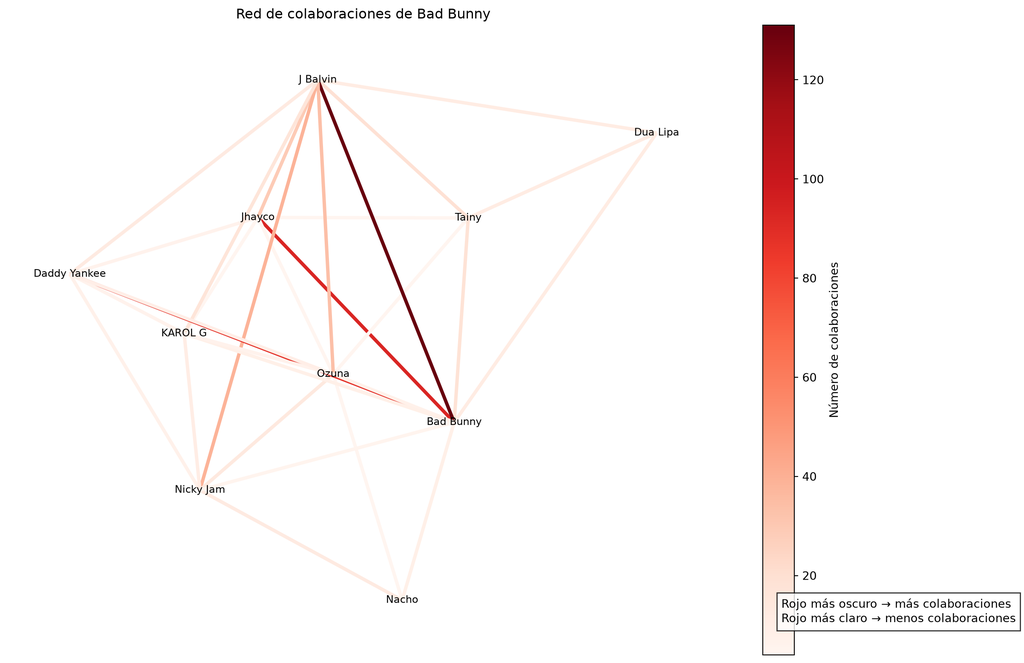

```python
import matplotlib.pyplot as plt
import matplotlib.cm as cm
import matplotlib.colors as colors

artista = "Bad Bunny"

# vecinos directos
vecinos = list(G.neighbors(artista))

subnodos = [artista] + vecinos[:20]

subG = G.subgraph(subnodos)

fig, ax = plt.subplots(figsize=(14,10))

pos = nx.spring_layout(subG, seed=42)

# obtener número de colaboraciones
collabs = [
subG[u][v]["collaborations"]
for u, v in subG.edges()
]

# normalización para colores
norm = colors.Normalize(
vmin=min(collabs),
vmax=max(collabs)
)

edge_colors = [
cm.Reds(norm(c))
for c in collabs
]


nx.draw_networkx_labels(
subG,
pos,
font_size=9
)


nx.draw_networkx_edges(
subG,
pos,
edge_color=edge_colors,
width=3
)

# barra de color
sm = plt.cm.ScalarMappable(
cmap=cm.Reds,
norm=norm
)

sm.set_array([])

ax = plt.gca()

cbar = plt.colorbar(
    sm,
    ax=ax,
    label="Número de colaboraciones"
)

# Texto explicativo de la escala
plt.figtext(
    0.80, 0.15,
    "Rojo más oscuro → más colaboraciones\nRojo más claro → menos colaboraciones",
    fontsize=10,
    bbox=dict(
        facecolor="white",
        edgecolor="black",
        alpha=0.8
    )
)

plt.title(
"Red de colaboraciones de Bad Bunny"
)

plt.axis("off")
plt.show()
```

Los resultados muestran que los artistas más cercanos a Bad Bunny dentro de la red de colaboraciones son J Balvin, Jhayco y Daddy Yankee. Esto indica que existen múltiples caminos de colaboración frecuentes que conectan a estos artistas, produciendo distancias muy reducidas dentro del grafo.

### 5.2 Modelo 2: Selección óptima de duetos mediante emparejamiento

Una vez calculadas las distancias entre artistas, el segundo modelo se encarga de seleccionar las parejas que formarán los nuevos duetos.

#### 5.2.1 Construcción del grafo

Se define un nuevo grafo no dirigido $G′=(V′,E′)$:

- Los nodos representan los artistas candidatos.
- Se crea una arista entre dos artistas únicamente si:
  - no han colaborado anteriormente;
  - su distancia calculada en el Modelo 1 es suficientemente pequeña.

Cada arista representa, por tanto, un posible nuevo dueto.

#### 5.2.2 Peso de las aristas

A cada posible pareja se le asigna una puntuación $w_{ij}$ que refleja el interés potencial de la colaboración.

Esta puntuación puede construirse a partir de diversos factores, como:

- la cercanía obtenida en el Modelo 1;
- la popularidad de los artistas;
- la similitud de características musicales;
- la complementariedad entre géneros.

Cuanto mayor sea el valor de $w_{ij}$, más recomendable se considera el dueto.

#### 5.2.3 Restricciones

Cada artista puede participar como máximo en una única pareja:

$$\sum_{j} x_{ij} \leq 1 \qquad \forall i$$
donde:

$$x_{ij} = \begin{cases}
1 & \text{si se selecciona el dueto } (i, j) \\
0 & \text{en otro caso}
\end{cases}$$

#### 5.2.4 Función objetivo

El objetivo consiste en maximizar la suma de las puntuaciones de las parejas seleccionadas:

$$\max \sum_{(i,j) \in E'} w_{ij} x_{ij}$$

Este problema corresponde a un problema de emparejamiento máximo ponderado (*Maximum Weight Matching*).

#### 5.2.5 Interpretación

Mientras que el Modelo 1 únicamente mide la cercanía entre artistas, el Modelo 2 decide qué parejas deben seleccionarse para maximizar la calidad global de las recomendaciones.

El resultado final es un conjunto de duetos en el que ningún artista aparece más de una vez y cuya puntuación total es máxima.

#### 5.2.6 Implementación en Python

##### 5.2.6.1 Calculamos candidatos a duelo

A continuación se construye el grafo de candidatos del Modelo 2. Para cada artista seleccionado se calculan las distancias obtenidas mediante el Modelo 1. Se consideran únicamente parejas de artistas que todavía no han colaborado y cuya distancia en la red es suficientemente reducida.

**Mostrar código**

```python
G2 = nx.Graph()

for artista in top_artistas:

    if artista not in G:
        continue

    distancias = calcular_distancias(artista)

    for otro, distancia in distancias.items():

        if otro not in top_artistas:
            continue

        if artista == otro:
            continue

        if G.has_edge(artista, otro):
            continue

        if distancia > 0.15:
            continue

        G2.add_edge(
            artista,
            otro,
            weight=1/distancia
        )

print("Nodos:", G2.number_of_nodes())
print("Posibles duetos:", G2.number_of_edges())
```

```
Nodos: 62
Posibles duetos: 288
```

##### 5.2.6.2 Obtenemos duetos óptimos

**Mostrar código**

```python
matching = nx.max_weight_matching(
    G2,
    maxcardinality=False
)

print("Número de duetos recomendados:", len(matching))
```

```
Número de duetos recomendados: 27
```

**Mostrar código**

```python
duetos = pd.DataFrame(
    list(matching),
    columns=["Artista 1", "Artista 2"]
)

duetos
```

|  | Artista 1 | Artista 2 |
| --- | --- | --- |
| 0 | Anne-Marie | Bastille |
| 1 | Charli XCX | Ava Max |
| 2 | Joel Corry | MEDUZA |
| 3 | Tove Lo | Katy Perry |
| 4 | Jhayco | Nicky Jam |
| 5 | Zion & Lennox | Tainy |
| 6 | Bebe Rexha | Ella Henderson |
| 7 | Maluma | Alvaro Diaz |
| 8 | Ozuna | Joey Montana |
| 9 | Giacomo Puccini | Giuseppe Verdi |
| 10 | Pritam | A.R. Rahman |
| 11 | Danielle Laval | London Symphony Orchestra |
| 12 | Justin Quiles | David Guetta |
| 13 | Clean Bandit | Marshmello |
| 14 | Maria Becerra | Daddy Yankee |
| 15 | Bad Bunny | Anuel AA |
| 16 | Justin Bieber | Selena Gomez |
| 17 | A7S | Dua Lipa |
| 18 | KAROL G | Chris Jedi |
| 19 | Anderson .Paak | Wiz Khalifa |
| 20 | Wisin & Yandel | J Balvin |
| 21 | Sean Paul | Calvin Harris |
| 22 | Topic | Mabel |
| 23 | Robin Schulz | Becky Hill |
| 24 | Tiësto | Mariah Angeliq |
| 25 | DJ Snake | Feid |
| 26 | FKA twigs | Swedish House Mafia |

### 5.3 Relación entre ambos modelos

Los dos modelos se ejecutan de forma secuencial:

1. El Modelo 1 calcula las distancias entre artistas dentro de la red de colaboraciones.
2. El Modelo 2 utiliza dichas distancias para construir el conjunto de duetos candidatos.
3. Finalmente, se selecciona el emparejamiento que maximiza la calidad global de las recomendaciones.

Por tanto, el primer modelo realiza el análisis estructural de la red, mientras que el segundo lleva a cabo la optimización de las decisiones finales.

## Footnotes

[^1]: Reddy, S. C. (s. f.). Spotify Tracks Dataset | Audio Features. Kaggle. Disponible en: https://www.kaggle.com/datasets/saichaitanyareddyai/spotify-tracks-dataset-audio-features